# Practical Machine Learning Course Project

Vladimir Mijatovic

2022-04-24

## Predicting how well the exercise is performed

The main goal of the project is the analysis of the manner of how well the exercise is performed.

### Background

Using devices such as *Jawbone Up*, *Nike FuelBand*, and *Fitbit* it is now possible to collect a large amount of data about personal activity relatively inexpensively. In this particular datased, a group of 6 participants have collected measures from various sensors while doing barbell lifts correctly and incorrectly.  
More information is available from the website here: http://web.archive.org/web/20161224072740/http:/groupware.les.inf.puc-rio.br/har (see the section on the Weight Lifting Exercise Dataset).

Correct performance is marked with “Class A”, while other classes are incorrect exercise (with mistakes).

### Prepare the Environment

Let’s prepare the environment

## Load and Prepare Data

First let’s load and prepare the data

```
## [1] "Dimensions of data are: 20"  "Dimensions of data are: 160"
```

We can see that test data has only `20` observations. It is better therefore to call this data `validationData`, and to partition *trainData* into two groups. But before partitioning we need to do some cleaning.

```r
validationData <- testData
testData <- NULL
```

# Exploratory Data Analisys

Let’s see all the data fields

```r
str(trainData, give.head = TRUE)
```

```
## 'data.frame':    19622 obs. of  160 variables:
##  $                         : int  1 2 3 4 5 6 7 8 9 10 ...
##  $ user_name               : chr  "carlitos" "carlitos" "carlitos" "carlitos" ...
##  $ raw_timestamp_part_1    : int  1323084231 1323084231 1323084231 1323084232 1323084232 1323084232 1323084232 1323084232 1323084232 1323084232 ...
##  $ raw_timestamp_part_2    : int  788290 808298 820366 120339 196328 304277 368296 440390 484323 484434 ...
##  $ cvtd_timestamp          : chr  "05/12/2011 11:23" "05/12/2011 11:23" "05/12/2011 11:23" "05/12/2011 11:23" ...
##  $ new_window              : chr  "no" "no" "no" "no" ...
##  $ num_window              : int  11 11 11 12 12 12 12 12 12 12 ...
##  $ roll_belt               : num  1.41 1.41 1.42 1.48 1.48 1.45 1.42 1.42 1.43 1.45 ...
##  $ pitch_belt              : num  8.07 8.07 8.07 8.05 8.07 8.06 8.09 8.13 8.16 8.17 ...
##  $ yaw_belt                : num  -94.4 -94.4 -94.4 -94.4 -94.4 -94.4 -94.4 -94.4 -94.4 -94.4 ...
##  $ total_accel_belt        : int  3 3 3 3 3 3 3 3 3 3 ...
##  $ kurtosis_roll_belt      : chr  "" "" "" "" ...
##  $ kurtosis_picth_belt     : chr  "" "" "" "" ...
##  $ kurtosis_yaw_belt       : chr  "" "" "" "" ...
```

[output cut: 86 more lines]

Let’s remove unnecessary variables. Variables that have a lot of NA should be removed. How many variables have lot of NAs?

```r
na_count <-sapply(trainData, function(y) sum(length(which(is.na(y)))))
na_count <- data.frame(na_count)
sum(na_count > 0)
```

```
## [1] 67
```

Seems like there are columns that are only NAs. These should be removed, as they can’t contribute to our prediction model.

```r
#get rid of columns where NAs are more than 90%
trainData <- trainData[, colMeans(is.na(trainData)) < 0.9]
validationData <- validationData[, colMeans(is.na(validationData)) < 0.9]

# get rid of columns that don't contribute (e.g. timestamp, name, etc)
trainData <- trainData[, -c(1:7)]
validationData <- validationData[, -c(1:7)]
```

### Remove Variables With Near-Zero Variance

We should remove variables that are having Near-Zero Variance, as they don’t contribute to our model either.

```r
near_zero_variables <- nearZeroVar(trainData)
```

These are variables that should be removed:

```r
names(trainData)[near_zero_variables]
```

```
##  [1] "kurtosis_roll_belt"      "kurtosis_picth_belt"
##  [3] "kurtosis_yaw_belt"       "skewness_roll_belt"
##  [5] "skewness_roll_belt.1"    "skewness_yaw_belt"
##  [7] "max_yaw_belt"            "min_yaw_belt"
##  [9] "amplitude_yaw_belt"      "kurtosis_roll_arm"
## [11] "kurtosis_picth_arm"      "kurtosis_yaw_arm"
## [13] "skewness_roll_arm"       "skewness_pitch_arm"
## [15] "skewness_yaw_arm"        "kurtosis_roll_dumbbell"
## [17] "kurtosis_picth_dumbbell" "kurtosis_yaw_dumbbell"
## [19] "skewness_roll_dumbbell"  "skewness_pitch_dumbbell"
## [21] "skewness_yaw_dumbbell"   "max_yaw_dumbbell"
## [23] "min_yaw_dumbbell"        "amplitude_yaw_dumbbell"
## [25] "kurtosis_roll_forearm"   "kurtosis_picth_forearm"
## [27] "kurtosis_yaw_forearm"    "skewness_roll_forearm"
## [29] "skewness_pitch_forearm"  "skewness_yaw_forearm"
## [31] "max_yaw_forearm"         "min_yaw_forearm"
## [33] "amplitude_yaw_forearm"
```

```r
trainData <- trainData[, -near_zero_variables]
```

### Partitioning

Now let’s partition training dataset. We partition it in 70% training and 30% testing set:

```r
inTrain <- createDataPartition(trainData$classe,
                               p = 0.7,
                               list = FALSE)

training_set <- trainData[inTrain, ]
testing_set <- trainData[-inTrain, ]

#check their dimensions
dim(training_set)
```

```
## [1] 13737    53
```

```r
dim(testing_set)
```

```
## [1] 5885   53
```

## Correlation Analysis

Let’s examine the correlation among those variable.

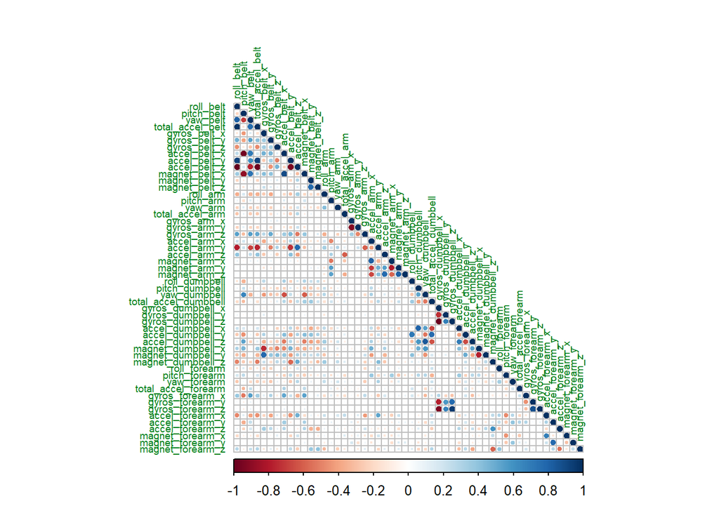

```r
corr_matrix <- cor(training_set[, -53])
corrplot(corr_matrix,
         type = "lower",
         tl.cex = 0.6,
         tl.col = rgb(0, .5, .1))
```

## Prediction Model Building

```r
# make it into factor and relevel (so that "A" is reference level)
training_set$classe <- factor(training_set$classe)
training_set$classe <- relevel(training_set$classe,
                            ref = "A")

testing_set$classe <- factor(testing_set$classe)
testing_set$classe <- relevel(testing_set$classe,
                            ref = "A")
```

Finally we can train our models and cross-validate. In order to estimate which model performs the best, we will use 3 different ML algorithms, and cross-validate to see their performance.

### Random Forest

Let’s train the model. We use in train control cross-validation method to avoid overfitting. We use 5-fold cross-validation.

```r
model_rf <- train(classe ~ .,
                  method = "rf",
                  data = training_set,
                  trControl = trainControl(
                          method = "cv",
                          number = 5),
                  allowParallel = TRUE)

model_rf$finalModel
```

```
##
## Call:
##  randomForest(x = x, y = y, mtry = min(param$mtry, ncol(x)), allowParallel = TRUE)
##                Type of random forest: classification
##                      Number of trees: 500
## No. of variables tried at each split: 27
##
##         OOB estimate of  error rate: 0.79%
## Confusion matrix:
##      A    B    C    D    E class.error
## A 3898    4    3    0    1 0.002048131
## B   20 2631    7    0    0 0.010158014
## C    0   14 2373    9    0 0.009599332
## D    0    3   31 2215    3 0.016429840
## E    0    1    5    8 2511 0.005544554
```

Let’s see how it performs on `testing_set`

```r
prediction_rf <- predict(model_rf,
                         newdata = testing_set)

conf_mat_rf <- confusionMatrix(prediction_rf, testing_set$classe)
conf_mat_rf
```

```
## Confusion Matrix and Statistics
##
##           Reference
## Prediction    A    B    C    D    E
##          A 1674    6    0    0    0
##          B    0 1131    4    0    0
##          C    0    2 1017   17    3
##          D    0    0    5  947    4
##          E    0    0    0    0 1075
##
## Overall Statistics
##
##                Accuracy : 0.993
##                  95% CI : (0.9906, 0.995)
##     No Information Rate : 0.2845
##     P-Value [Acc > NIR] : < 2.2e-16
##
##                   Kappa : 0.9912
##
##  Mcnemar's Test P-Value : NA
##
## Statistics by Class:
##
##                      Class: A Class: B Class: C Class: D Class: E
## Sensitivity            1.0000   0.9930   0.9912   0.9824   0.9935
## Specificity            0.9986   0.9992   0.9955   0.9982   1.0000
## Pos Pred Value         0.9964   0.9965   0.9788   0.9906   1.0000
## Neg Pred Value         1.0000   0.9983   0.9981   0.9966   0.9985
## Prevalence             0.2845   0.1935   0.1743   0.1638   0.1839
## Detection Rate         0.2845   0.1922   0.1728   0.1609   0.1827
## Detection Prevalence   0.2855   0.1929   0.1766   0.1624   0.1827
## Balanced Accuracy      0.9993   0.9961   0.9934   0.9903   0.9968
```

The accuracy is 0.9930331

### XGBoost

XGBoost has shown to be one of the most successful machine learning algorithms. Let’s see how it will work here. We build model, as always, on training_set, using 5-fold cross-validation to reduce overfitting.

[output not shown]

[output cut: 305 more lines]

[output not shown]

```
## ##### xgb.Booster
## raw: 821.5 Kb
## call:
##   xgboost::xgb.train(params = list(eta = param$eta, max_depth = param$max_depth,
##     gamma = param$gamma, colsample_bytree = param$colsample_bytree,
##     min_child_weight = param$min_child_weight, subsample = param$subsample),
##     data = x, nrounds = param$nrounds, num_class = length(lev),
##     objective = "multi:softprob")
## params (as set within xgb.train):
##   eta = "0.4", max_depth = "3", gamma = "0", colsample_bytree = "0.8", min_child_weight = "1", subsample = "0.75", num_class = "5", objective = "multi:softprob", validate_parameters = "TRUE"
## xgb.attributes:
##   niter
## callbacks:
##   cb.print.evaluation(period = print_every_n)
## # of features: 52
## niter: 150
## nfeatures : 52
## xNames : roll_belt pitch_belt yaw_belt total_accel_belt gyros_belt_x gyros_belt_y gyros_belt_z accel_belt_x accel_belt_y accel_belt_z magnet_belt_x magnet_belt_y magnet_belt_z roll_arm pitch_arm yaw_arm total_accel_arm gyros_arm_x gyros_arm_y gyros_arm_z accel_arm_x accel_arm_y accel_arm_z magnet…
## problemType : Classification
## tuneValue :
##      nrounds max_depth eta gamma colsample_bytree min_child_weight subsample
## 105     150         3 0.4     0              0.8                1      0.75
## obsLevels : A B C D E
## param :
##  list()
```

Let’s see how it performs on `testing_set`

```r
prediction_xgboost <- predict(model_xgboost,
                         newdata = testing_set)

conf_mat_xgboost <- confusionMatrix(prediction_xgboost, testing_set$classe)
conf_mat_xgboost
```

```
## Confusion Matrix and Statistics
##
##           Reference
## Prediction    A    B    C    D    E
##          A 1670    1    0    0    0
##          B    1 1134    9    0    0
##          C    3    3 1016    8    1
##          D    0    0    1  956    1
##          E    0    1    0    0 1080
##
## Overall Statistics
##
##                Accuracy : 0.9951
##                  95% CI : (0.9929, 0.9967)
##     No Information Rate : 0.2845
##     P-Value [Acc > NIR] : < 2.2e-16
##
##                   Kappa : 0.9938
##
##  Mcnemar's Test P-Value : NA
##
## Statistics by Class:
##
##                      Class: A Class: B Class: C Class: D Class: E
## Sensitivity            0.9976   0.9956   0.9903   0.9917   0.9982
## Specificity            0.9998   0.9979   0.9969   0.9996   0.9998
## Pos Pred Value         0.9994   0.9913   0.9855   0.9979   0.9991
## Neg Pred Value         0.9991   0.9989   0.9979   0.9984   0.9996
## Prevalence             0.2845   0.1935   0.1743   0.1638   0.1839
## Detection Rate         0.2838   0.1927   0.1726   0.1624   0.1835
## Detection Prevalence   0.2839   0.1944   0.1752   0.1628   0.1837
## Balanced Accuracy      0.9987   0.9968   0.9936   0.9956   0.9990
```

It accuracy is 0.9950722

### Decision Tree

Now we should try with simple Decision Tree model, also using 5-fold cross-validation to avoid overfitting.

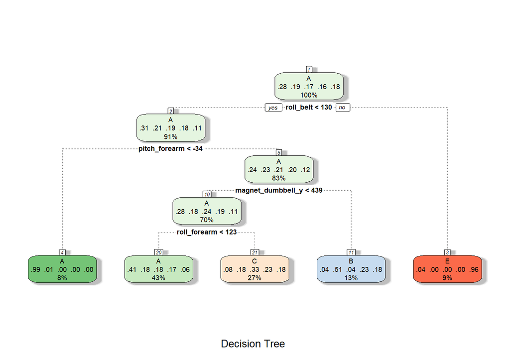

```r
train_control <- trainControl(method="cv", number=5, verboseIter=F)

model_trees <- train(classe ~ .,
                   method = "rpart",
                   trControl = train_control,
                   data = training_set)

rattle::fancyRpartPlot(model_trees$finalModel,
                       sub = "Decision Tree")
```

Let’s see how it performs on `testing_set`

```r
prediction_trees <- predict(model_trees,
                         newdata = testing_set)

conf_mat_rpart <- confusionMatrix(prediction_trees, testing_set$classe)
conf_mat_rpart
```

```
## Confusion Matrix and Statistics
##
##           Reference
## Prediction    A    B    C    D    E
##          A 1500  478  496  434  152
##          B   23  386   32  160  153
##          C  124  275  498  370  273
##          D    0    0    0    0    0
##          E   27    0    0    0  504
##
## Overall Statistics
##
##                Accuracy : 0.4907
##                  95% CI : (0.4779, 0.5036)
##     No Information Rate : 0.2845
##     P-Value [Acc > NIR] : < 2.2e-16
##
##                   Kappa : 0.3344
##
##  Mcnemar's Test P-Value : NA
##
## Statistics by Class:
##
##                      Class: A Class: B Class: C Class: D Class: E
## Sensitivity            0.8961  0.33889  0.48538   0.0000  0.46580
## Specificity            0.6295  0.92246  0.78555   1.0000  0.99438
## Pos Pred Value         0.4902  0.51194  0.32338      NaN  0.94915
## Neg Pred Value         0.9384  0.85324  0.87848   0.8362  0.89204
## Prevalence             0.2845  0.19354  0.17434   0.1638  0.18386
## Detection Rate         0.2549  0.06559  0.08462   0.0000  0.08564
## Detection Prevalence   0.5200  0.12812  0.26168   0.0000  0.09023
## Balanced Accuracy      0.7628  0.63068  0.63547   0.5000  0.73009
```

Accuracy of simple Decision Tree model is only 0.4907392, which is clearly inferior to Random Forest and XGBoost.

# Conclusion

# Predicting on validationData

Let’s use XGBoost to predict on validation data:

```
## [1] "XGBoost: "
```

```
##    problem_id prediction
## 1           1          B
## 2           2          A
## 3           3          B
## 4           4          A
## 5           5          A
## 6           6          E
## 7           7          D
## 8           8          B
## 9           9          A
## 10         10          A
## 11         11          B
## 12         12          C
## 13         13          B
## 14         14          A
## 15         15          E
## 16         16          E
## 17         17          A
## 18         18          B
## 19         19          B
## 20         20          B
```